# 10. 现代循环神经网络

Deep Learning I

10. 现代循环神经网络

WU Xiaokun 吴晓堃

xkun.wu [at] gmail

2022/05/04

# 长短期记忆网络（LSTM）

## 回顾：隐变量模型的信息传递

当前隐状态$\textbf{H}_t$**整合过去所有**的观测信息

$$\begin{aligned}
\textbf{H}_t &= \sigma(\textbf{X}_t \textbf{W}_x^h +
\textbf{H}_{t-1} \textbf{W}_h^h + \textbf{b}^h)\\
\textbf{O}_t &= \textbf{H}_t \textbf{W}_h^o + \textbf{b}^o\\
\end{aligned}$$

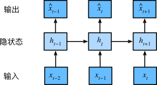

不同时间步使用**相同参数**：$\textbf{W}_x^h, \textbf{W}_h^h, \textbf{W}_h^o, b^h, b^o$

- 每个时间步整合新的观测：长期信息在不断更新中逐渐消失
  - 模型架构、**存储空间固定**：新信息必定挤占旧信息的位置，类比监控磁盘

[Hochreiter 1997] LSTM：引入类似逻辑门电路的**记忆元**

- 根据需要（重要程度）选择保存、丢弃信息：解决**信息选取**的问题

## LSTM：输入门、忘记门、输出门

门控：决定信息**整合比例**（类比电流，可想象成水阀）

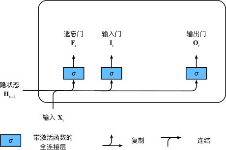

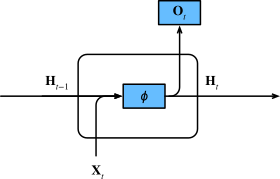

$$\begin{aligned}
\textbf{I}_t &= \sigma(\textbf{X}_t \textbf{W}_x^i +
\textbf{H}_{t-1} \textbf{W}_h^i + \textbf{b}^i)\\
\textbf{F}_t &= \sigma(\textbf{X}_t \textbf{W}_x^f +
\textbf{H}_{t-1} \textbf{W}_h^f + \textbf{b}^f)\\
\textbf{O}_t &= \sigma(\textbf{X}_t \textbf{W}_x^o +
\textbf{H}_{t-1} \textbf{W}_h^o + \textbf{b}^o)\\
\end{aligned}$$

$$\begin{aligned}
\textbf{H}_t &= \sigma(\textbf{X}_t \textbf{W}_x^h +
\textbf{H}_{t-1} \textbf{W}_h^h + \textbf{b}^h)\\
\textbf{O}_t &= \textbf{H}_t \textbf{W}_h^o + \textbf{b}^o\\
\end{aligned}$$

## LSTM：候选记忆元

候选记忆：来自当前时间步的**编码信息**

$$\begin{aligned}
\tilde{\textbf{C}}_t &= \tanh(\textbf{X}_t \textbf{W}_x^c +
\textbf{H}_{t-1} \textbf{W}_h^c + \textbf{b}^c)\\
\end{aligned}$$

- `tanh`激活：只挤压，不截取

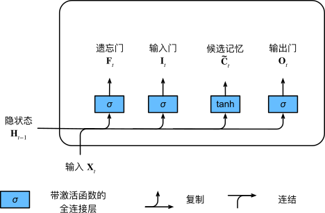

- 对比门控（`sigma`激活）：从信息本身分析重要程度，即**权重值**

## LSTM：记忆元

输入门$\textbf{I}_t$控制**采用**多少来自$\tilde{\textbf{C}}_t$的新数据；遗忘门$\textbf{F}_t$控制**保留**多少过去的记忆$\textbf{C}_{t-1}$

$$\begin{aligned}
\textbf{C}_t &= \textbf{F}_t \odot \textbf{C}_{t-1} + \textbf{I}_t
\odot \tilde{\textbf{C}}_t\\
\end{aligned}$$

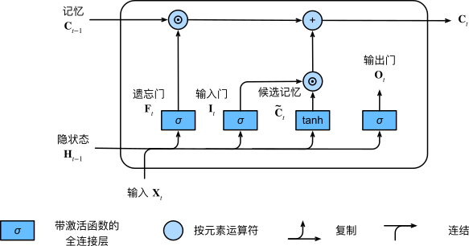

例如$\textbf{F}_t = 1, \textbf{I}_t = 0$：**所有记忆都保存**并传递到当前时间步

- 缓解梯度消失问题，并捕获**长距离依赖**关系
- 反之，$\textbf{F}_t = 0, \textbf{I}_t = 1$：重置记忆，由当前时间步初始化

## LSTM：隐状态

输出门$\textbf{O}_t$控制**传出**多少更新后的记忆$\textbf{C}_t$

$$\begin{aligned}
\textbf{H}_t &= \textbf{O}_t \odot \tanh(\textbf{C}_{t})\\
\end{aligned}$$

- `tanh`激活：只挤压，不截取

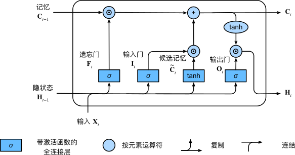

例如$\textbf{O}_t = 1$：**所有记忆都传递**给预测

- $\textbf{O}_t = 0$：记忆传递给下一时间步；隐状态清零

注意：只有隐状态$\textbf{H}_t$**传递到输出层**；记忆元$\textbf{C}_t$不直接参与输出计算

- 思考：似乎记忆元与隐状态的作用有些类似？

## 实验：LSTM

## 小结：LSTM

- LSTM使用三种门控单元：输入门、遗忘门、输出门
  - 输出小数（百分比）：想象成水阀
- 隐藏层输出：隐状态（传递到输出层）、记忆元（内部传递）
  - 输出挤压到$(-1,1)$：归一化的信息
- 缓解梯度消失、梯度爆炸；可以捕获长距离依赖关系

# 门控循环单元（GRU）

## LSTM的计算问题

$$\begin{aligned}
\textbf{I}_t &= \sigma(\textbf{X}_t \textbf{W}_x^i +
\textbf{H}_{t-1} \textbf{W}_h^i + \textbf{b}^i)\\
\textbf{F}_t &= \sigma(\textbf{X}_t \textbf{W}_x^f +
\textbf{H}_{t-1} \textbf{W}_h^f + \textbf{b}^f)\\
\textbf{O}_t &= \sigma(\textbf{X}_t \textbf{W}_x^o +
\textbf{H}_{t-1} \textbf{W}_h^o + \textbf{b}^o)\\
\tilde{\textbf{C}}_t &= \tanh(\textbf{X}_t \textbf{W}_x^c +
\textbf{H}_{t-1} \textbf{W}_h^c + \textbf{b}^c)\\
\textbf{C}_t &= \textbf{F}_t \odot \textbf{C}_{t-1} + \textbf{I}_t
\odot \tilde{\textbf{C}}_t\\
\textbf{H}_t &= \textbf{O}_t \odot \tanh(\textbf{C}_{t})\\
\textbf{Y}_t &= \textbf{H}_t \textbf{W}_h^y + \textbf{b}^y\\
\end{aligned}$$

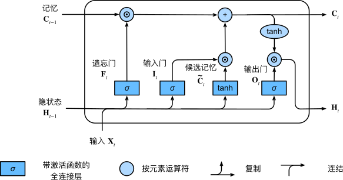

参数：$\textbf{W}_x^i, \textbf{W}_h^i, \textbf{W}_x^f, \textbf{W}_h^f, \textbf{W}_x^o, \textbf{W}_h^o, \textbf{W}_x^c, \textbf{W}_h^c, \textbf{W}_h^y, b^i, b^f, b^o, b^c, \textbf{b}^y$

[Cho 2014] GRU：（**简化**的）门控循环网络，且将记忆元**合并**到隐状态

## GRU：重置门、更新门

重置门：控制“**可能还想记住**”的候选隐状态数量；更新门：控制**更新比例**

$$\begin{aligned}
\textbf{R}_t &= \sigma(\textbf{X}_t \textbf{W}_x^r +
\textbf{H}_{t-1} \textbf{W}_h^r + \textbf{b}^r)\\
\textbf{Z}_t &= \sigma(\textbf{X}_t \textbf{W}_x^z +
\textbf{H}_{t-1} \textbf{W}_h^z + \textbf{b}^z)\\
\end{aligned}$$

- `sigma`激活：转换成权重（百分比）值

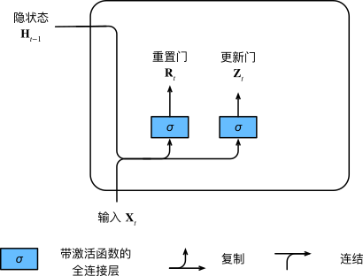

## GRU：候选隐状态

$\textbf{R}_t$门控：取值$(0,1)$，减少以往隐状态的影响

$$\begin{aligned}
\tilde{\textbf{H}}_t &= \tanh(\textbf{X}_t \textbf{W}_x^h +
(\mathbf{R}_t \odot \textbf{H}_{t-1}) \textbf{W}_h^h + \textbf{b}^h)\\
\end{aligned}$$

- `tanh`激活：只挤压，不截取

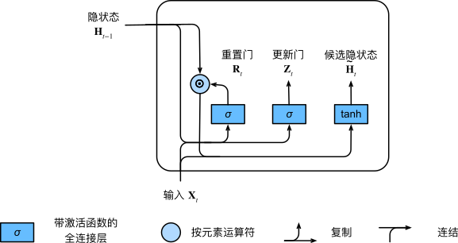

例如$\textbf{R}_t = 1$：**所有隐状态都传递**，等价于普通循环网络

- $\textbf{R}_t = 0$：所有隐状态重置，等价于多层感知机

## GRU：隐状态

$\textbf{Z}_t$门控：决定新、旧隐状态整合的比例

$$\begin{aligned}
\textbf{H}_t &= \textbf{Z}_t \odot \textbf{H}_{t-1} + (1 -
\textbf{Z}_t) \odot \tilde{\textbf{H}}_t\\
\end{aligned}$$

- 记忆元合并到隐状态

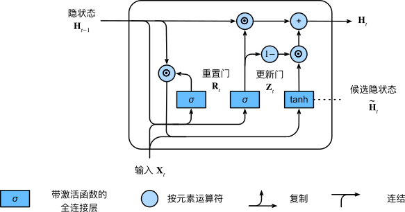

例如$\textbf{Z}_t = 1$：只保留旧状态，即跳过当前时间步

- 缓解梯度消失问题，并捕获**长距离依赖**关系
- $\textbf{Z}_t = 0$：只传递候选隐状态

## GRU：计算量

$$\begin{aligned}
\textbf{R}_t &= \sigma(\textbf{X}_t \textbf{W}_x^r +
\textbf{H}_{t-1} \textbf{W}_h^r + \textbf{b}^r)\\
\textbf{Z}_t &= \sigma(\textbf{X}_t \textbf{W}_x^z +
\textbf{H}_{t-1} \textbf{W}_h^z + \textbf{b}^z)\\
\tilde{\textbf{H}}_t &= \tanh(\textbf{X}_t \textbf{W}_x^h +
(\mathbf{R}_t \odot \textbf{H}_{t-1}) \textbf{W}_h^h + \textbf{b}^h)\\
\textbf{H}_t &= \textbf{Z}_t \odot \textbf{H}_{t-1} + (1 -
\textbf{Z}_t) \odot \tilde{\textbf{H}}_t\\
\textbf{Y}_t &= \textbf{H}_t \textbf{W}_h^y + \textbf{b}^y\\
\end{aligned}$$

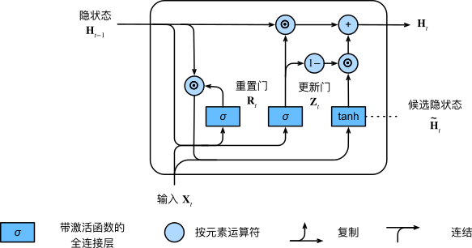

参数：$\textbf{W}_x^r, \textbf{W}_h^r, \textbf{W}_x^z, \textbf{W}_h^z, \textbf{W}_x^h, \textbf{W}_h^h, \textbf{W}_h^y, b^r, b^z, b^h, \textbf{b}^y$

LSTM：$\textbf{W}_x^i, \textbf{W}_h^i, \textbf{W}_x^f, \textbf{W}_h^f, \textbf{W}_x^o, \textbf{W}_h^o, \textbf{W}_x^c, \textbf{W}_h^c, \textbf{W}_h^y, b^i, b^f, b^o, b^c, \textbf{b}^y$

参数少，但功能不少：更简单的效能更好

## 实验：GRU

## 小结：GRU

- GRU使用两种门控单元：重置门、更新门
  - 只有一个隐状态：记忆元合并到隐状态
- 缓解梯度消失问题；可以捕获长距离依赖关系

# 深度循环神经网络

## 回顾：隐变量模型的表达能力

当前隐状态$\textbf{H}_t$**整合过去所有**的观测信息

$$\begin{aligned}
\textbf{H}_t &= \sigma(\textbf{X}_t \textbf{W}_x^h +
\textbf{H}_{t-1} \textbf{W}_h^h + \textbf{b}^h)\\
\textbf{O}_t &= \textbf{H}_t \textbf{W}_h^o + \textbf{b}^o\\
\end{aligned}$$

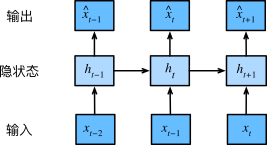

- 隐状态$\textbf{H}_t$产生**信息瓶颈**：融合之前所有信息
  - 对当前时间步的观测信息$\textbf{X}_t$**编码、描述不足**

如何获得更多**非线性**、构造更复杂模型？思考感知机的设计（多层变换解决 XOR 问题）

## DRNN：架构

深度循环神经网络：隐藏层的**堆叠**

隐状态的**两个信息流向**

- 当前层的下一时间步
  - 横列构成 HMM
- 下一层的当前时间步
  - 纵列构成感知机

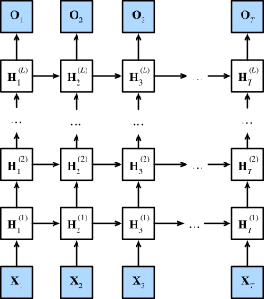

## DRNN：计算

深度循环神经网络：隐藏层的**堆叠**

$$\begin{aligned}
\textbf{H}_t^{(l)} &= \sigma(\textbf{X}_t^{(l-1)}
\textbf{W}_x^{h^{(l)}} + \textbf{H}_{t-1}^{(l)} \textbf{W}_h^{h^{(l)}} +
\textbf{b}^{h^{(l)}})\\
\textbf{O}_t &= \textbf{H}_t^{(L)} \textbf{W}_h^o + \textbf{b}^o\\
\end{aligned}$$

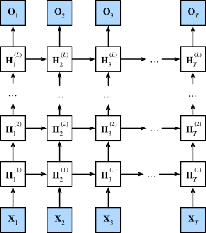

## 实验：DRNN

## 小结：DRNN

- DRNN：隐藏层横向、纵向分别传递信息
- 超参数：隐变量数、层数

# 双向循环神经网络

## 文本生成、完形填空

文本生成：预测下一个位置

```
他下课后去了 __ __ 。
```

完形填空：后文对当前预测**反向传递**提示信息

```
她把 __ __
她把 __ __ 递给了老师。
她把 __ __ 递给了老师，然后飞走了。
```

## 隐Markov模型 HMM

一阶HMM的两个假设

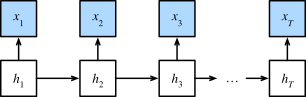

- 一阶Markov假设：状态概率只取决于**前一个**状态
  - 称为**状态转移概率**

$$P(h_t|h_1,..,h_{t-1}) \approx P(h_t|h_{t-1})$$

- 独立性假设：输出变量的概率只取决于**直接关联**的隐变量
  - 称为**观测似然**，或“**发射概率**”

$$P(x_t|h_1,..,h_{T},x_1,..,x_T) \approx P(x_t|h_{t})$$

## 观测序列的概率

文本生成：预测下一个位置；等价于计算整个预测序列的概率

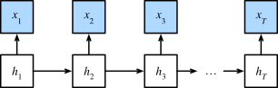

$$\begin{aligned}
P(x_1,..,x_T) &= \sum_{h_1,..,h_{T}} P(x_1,..,x_T,h_1,..,h_{T})\\
&= \sum_{h_1,..,h_{T}} \prod_t P(x_t|h_{t})P(h_t|h_{t-1})\\
\end{aligned}$$

- Viterbi 算法：动态规划

## 双向RNN模型

完形填空：后文对当前预测**反向传递**提示信息

隐状态的两个信息流向

- 隐藏层：前向、后向分别传递
- 输出：整合两个方向的隐状态

## 双向RNN模型：计算

完形填空：后文对当前预测**反向传递**提示信息

$$\begin{aligned}
\textbf{H}_t^{(f)} &= \sigma(\textbf{X}_t \textbf{W}_x^{h^{(f)}} +
\textbf{H}_{t-1}^{(f)} \textbf{W}_h^{h^{(f)}} + \textbf{b}^{h^{(f)}})\\
\textbf{H}_t^{(b)} &= \sigma(\textbf{X}_t \textbf{W}_x^{h^{(b)}} +
\textbf{H}_{t-1}^{(b)} \textbf{W}_h^{h^{(b)}} + \textbf{b}^{h^{(b)}})\\
\textbf{O}_t &= \textbf{H}_t \textbf{W}_h^o + \textbf{b}^o\\
\end{aligned}$$

- $\textbf{H}_t$：$\textbf{H}_t^{(f)}$、$\textbf{H}_t^{(b)}$的拼接

## 双向RNN模型：应用

不能用于“单边预测”，例如不能用未来信息预测现在

- 预测时无法获得对应数据

计算缓慢：两倍传递链

常用场合：填充缺失、词元标注、机器翻译

## 实验：BiRNN

## 小结：BiRNN

- BiRNN：隐藏层前向、后向分别传递时序信息
- 应用：特征提取、完形填空、词元标注、机器翻译
  - 不能用于“单边预测”

# Review

## 本章内容

长短期记忆网络（LSTM）。门控循环单元（GRU）。深度循环神经网络。双向循环神经网络。

**重点**：LSTM 的设计特点、网络架构；GRU 的设计特点、网络架构；深度循环神经网络的信息流向、网络架构；双向循环神经网络的信息流向、网络架构。

**难点**：现代循环神经网络的实现。

## 学习目标

- 理解 LSTM 的设计特点（门控，记忆元）、网络架构
- 理解 GRU 设计特点（简化门控，合并记忆元到隐状态）、网络架构
- 理解深度循环神经网络的信息流向、网络架构。
- 理解双向循环神经网络的信息流向、网络架构。

## 问题

简述 LSTM 的设计特点、网络架构。

简述 GRU 的设计特点、网络架构。

简述深度循环神经网络的信息流向、网络架构。

简述双向循环神经网络的信息流向、网络架构。